# Density estimation: Bandwidht choice by leave-one-out maximum likelihood

Adrià Casanova, Silvia Ferrer, Matteo Mazzini

2024-10-10

# Histogram

## 1.

We assume the intervals of the histogram to have constant width $b$. Then,
$$\hat{f}_{hist}(x_i) = \frac{1}{nb}\sum_{k=1}^{n}I_{B_{j(x_k)}}(x_i) =
\frac{1}{nb}\sum_{k \neq i}^{n}I_{B_{j(x_k)}}(x_i) + \frac{1}{nb}$$

On the other hand,
$$\hat{f}_{hist, (-i)}(x_i) = \frac{1}{(n-1)b}\sum_{k \neq
i}^{n}I_{B_{j(x_k)}}(x_i)$$

Hence, we get the following relationship between the histogram estimator of the density function and its leave-one-out version, when both are evaluated at $x_i$:
$$\hat{f}_{hist}(x_i) = \frac{n}{n-1}\Big(\hat{f}_{hist}(x_i) -
\frac{1}{nb}\Big)$$

## 2. and 3.

In the following graph we can see how indeed the histogram is a piece-wise constant function defined on the range of our data. Moreover, $\hat{f}_{hist,(-i)}(x_i)$ is close to $\hat{f}_{hist}(x_i)$, as $n=69$ is large.

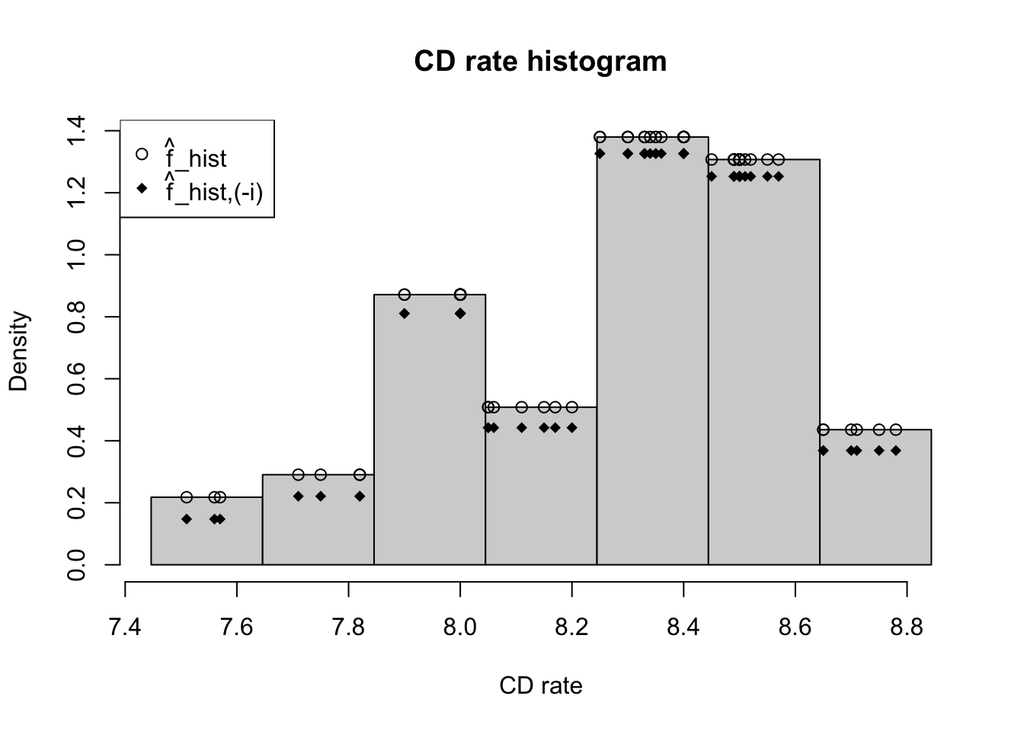

```r
########################
# 2.
########################
#Read data
cdrate.df <-read.table("cdrate.dat")
x <- cdrate.df[,1]

A <- min(x)-.05*diff(range(x))
Z <- max(x)+.05*diff(range(x))
nbr <- 7

#Histogram of x
hx <- hist(x,breaks=seq(A,Z,length=nbr+1),freq=F
           , main = "CD rate histogram", xlab = "CD rate")
hx_f <- stepfun(hx$breaks,c(0,hx$density,0))

#Add the points (x_i, \hat{f}_{hist}(x_i)) to the histogram
hx_f_xi <- hx_f(x)
points(x,hx_f_xi, pch=1)

########################
# 3.
########################
#Compute \hat{f}_{hist,(-i)}(x_i)
n <- length(x)
b <- hx$breaks[2] - hx$breaks[1]
hx_i_f_xi <- n/(n-1) * (hx_f(x) - 1/(n*b))

#Add the points (x_i, \hat{f}_{hist,(-i)}(x_i)) to the histogram
points(x, hx_i_f_xi, pch = 18)
legend("topleft", c(TeX(r"{\hat{f}_{hist}}"), TeX(r"{\hat{f}_{hist,(-i)}}")),
       pch=c(1,18))
```

## 4.

Taking 7 as the number of intervals, the log-likelihood value calculated with the LOOCV method is the following:

```r
hx_i_f_xi[hx_i_f_xi == 0] <- .Machine$double.eps #avoid log 0
log_lik <- sum(log(hx_i_f_xi))
cat("Leave-One-Out Log-Likelihood:", log_lik, "\n")
```

```
## Leave-One-Out Log-Likelihood: -16.58432
```

## 5.

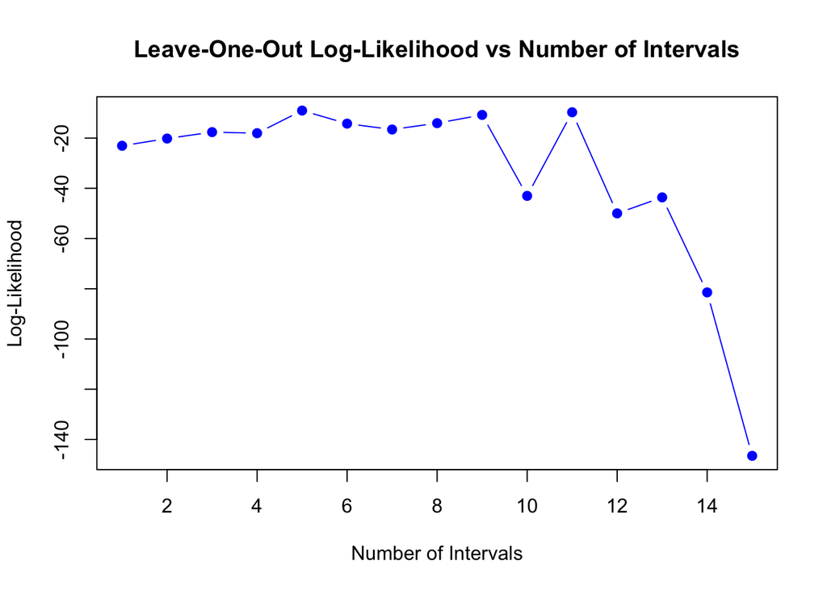

```r
nbr_values <- seq(1, 15)

loocv_nbr <- function(nbr) {
  hx <- hist(x, breaks=seq(A, Z, length=nbr+1), plot=F)
  hx_f <- stepfun(hx$breaks, c(0, hx$density, 0))
  hx_f_xi <- hx_f(x)

  b <- hx$breaks[2] - hx$breaks[1]
  hx_i_f_xi <- n/(n-1) * (hx_f(x) - 1/(n*b))

  # Compute the leave-one-out log-likelihood for each nbr
  hx_i_f_xi[hx_i_f_xi  < .Machine$double.eps] <- .Machine$double.eps #avoid log 0 or small negative values
  return(sum(log(hx_i_f_xi)))
}
looCV_log_lik <- lapply(nbr_values, loocv_nbr)

# Plot looCV_log_lik against nbr values
plot(nbr_values, looCV_log_lik, type="b", pch=19, col="blue",
     main="Leave-One-Out Log-Likelihood vs Number of Intervals",
     xlab="Number of Intervals", ylab="Log-Likelihood")
```

```r
# Find the optimal nbr
opt_nbr <- nbr_values[which.max(looCV_log_lik)]
cat("Optimal number of intervals", opt_nbr, "\n")
```

```
## Optimal number of intervals 5
```

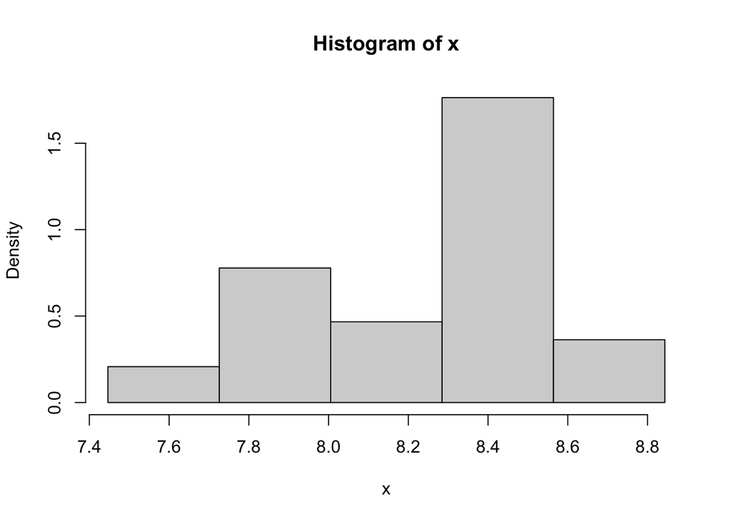

```r
# Plot histogram using the optimal nbr
hx_opt_nbr <- hist(x,breaks=seq(A,Z,length=opt_nbr+1), plot=F)
plot(hx_opt_nbr, freq=FALSE)
```

Looking at the first plot we can see that the number of intervals that maximizes the log-likelihood is 5, but we also see that 11 intervals is the second one. The resulting histogram employs this optimal number of intervals, previously calculated with the LOOCV, effectively capturing the underlying distribution.

## 6.

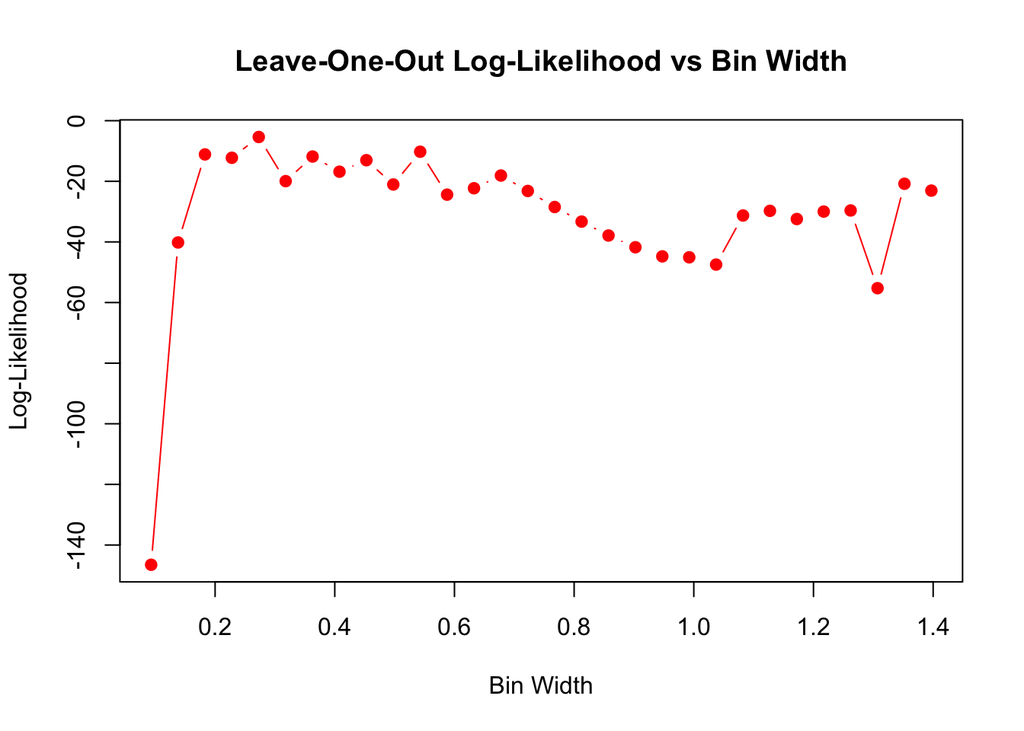

```r
b_values <- seq((Z-A)/15, (Z-A)/1, length=30)
looCV_log_lik_b <- sapply(b_values,function(b) {
  hx <- hist(x, breaks=seq(A, Z+b, by=b), plot=F)
  hx_f <- stepfun(hx$breaks, c(0, hx$density, 0))
  hx_i_f_xi <- n/(n-1) * (hx_f(x) - 1/(n*b))
  # Compute the leave-one-out log-likelihood for each b
  hx_i_f_xi[hx_i_f_xi <= 0] <- .Machine$double.eps #avoid log 0 or negative
  looCV_log_lik_b <- sum(log(hx_i_f_xi))
})

# Plot looCV_log_lik_b against b values
plot(b_values, looCV_log_lik_b, type="b", pch=19, col="red",
     main="Leave-One-Out Log-Likelihood vs Bin Width",
     xlab="Bin Width", ylab="Log-Likelihood")
```

```r
# Find the optimal bin width
opt_b <- b_values[which.max(looCV_log_lik_b)]
cat("Optimal bin width:", opt_b, "\n")
```

```
## Optimal bin width: 0.272977
```

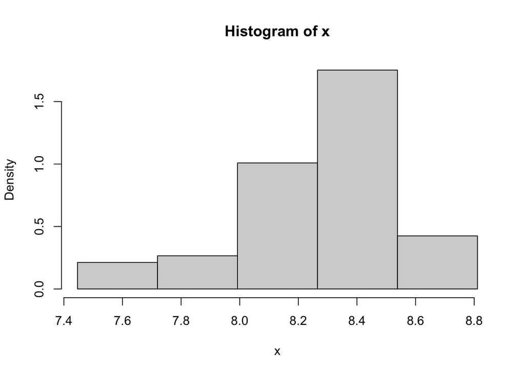

```r
# Plot histogram using the optimal bin width
hx_opt_b <- hist(x,breaks=seq(A,Z+b,by=opt_b), plot=F)
plot(hx_opt_b, freq=FALSE)
```

Similar to the previous approach, we calculated the optimal parameter, the bin width, using the LOOCV method, and after plotted the resulting histogram. The bin width that maximized the log-likelihood function was selected, ensuring a robust fit to the underlying distribution of the data.

## 7.

Now, we will use the functions `graph.mixt` and `sim.mixt` from the previous lab session to generate data from the following mixture of two normal distributions:

$$f(x) = \frac{3}{4} N(x; \mu = 0, \sigma = 1) + \frac{1}{4} N(x; \mu =
\frac{3}{2}, \sigma = \frac{1}{3})$$

```r
#generate data
set.seed(123)
n <- 100
mu <- c(0,3/2)
sigma <- c(1,1/3)
alpha <- c(3/4,1/4)
x <- sim.mixt(n=n, k=2, mu=mu, sigma=sigma, alpha=alpha, gr=F)
A <- min(x)-.05*diff(range(x))
Z <- max(x)+.05*diff(range(x))
b_values <- seq((Z-A)/15, (Z-A)/1, length=30)
n <- length(x)
#LOOCV-loglikelihood function
looCV_log_lik_b <- sapply(b_values, function(b) {
  hx <- hist(x, breaks=seq(A, Z+b, by=b), plot=F)
  hx_f <- stepfun(hx$breaks, c(0, hx$density, 0))
  hx_i_f_xi <- n/(n-1) * (hx_f(x) - 1/(n*b))
  hx_i_f_xi[hx_i_f_xi <= 0] <- .Machine$double.eps #avoid log 0 or negative
  looCV_log_lik_b <- sum(log(hx_i_f_xi))
})
opt_b <- b_values[which.max(looCV_log_lik_b)]
#histogram using the optimal bin width
hx_opt_b <- hist(x,breaks=seq(A,Z+b,by=opt_b), plot=F)
#comapare it with scott's formula
b_Scott <- 3.49 * sd(x) * length(x)^(-1/3)
hx_scotts_b <- hist(x,breaks=seq(A,Z+b,by=b_Scott), plot=F)
cat("Optimal bin width:", opt_b, "\n")
```

```
## Optimal bin width: 0.9664895
```

```r
cat("Optimal Scott's bin width:", b_Scott, "\n")
```

```
## Optimal Scott's bin width: 0.8311985
```

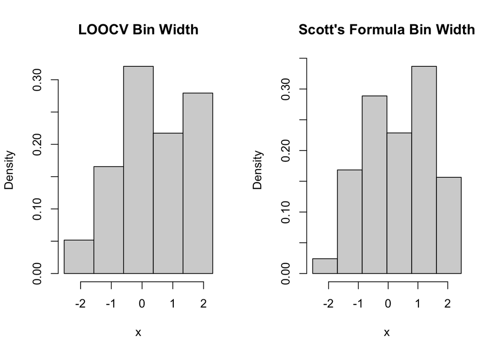

```r
par(mfrow= c(1,2))
plot(hx_opt_b, freq=FALSE, main="LOOCV Bin Width")
plot(hx_scotts_b, freq=FALSE, main="Scott's Formula Bin Width")
```

```r
#create h:values as before
h_values<- seq((Z-A)/15,(Z-A)/1,length=30)
#LOOCV-loglikelihood
looCV_log_lik_h <- sapply(h_values,function(h){
  kx <- density(x, bw = h)
  kx_f <- approxfun(kx$x, kx$y, method = 'linear', rule = 2)
  kx_i_f_xi<- (n / (n - 1)) * (kx_f(x) - dnorm(0)/ (n * h))
  kx_i_f_xi[kx_i_f_xi <= 0] <- .Machine$double.eps #avoid log 0 or negative
  looCV_log_lik_h <- sum(log(kx_i_f_xi))
})
opt_h <- h_values[which.max(looCV_log_lik_h)]
cat("Optimal bin width:", opt_h, "\n")
```

```
## Optimal bin width: 0.3297435
```

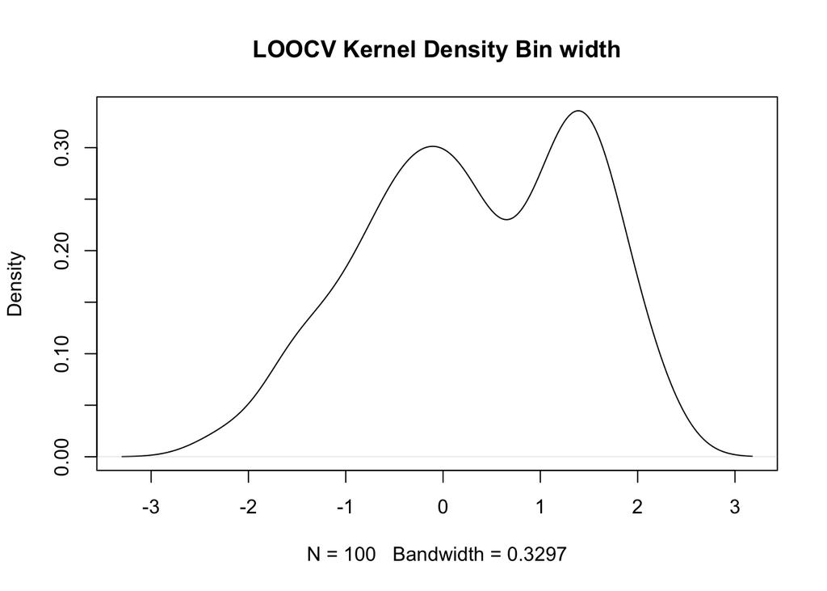

```r
kx_opt <- density(x, bw = opt_h)
plot(kx_opt, main = 'LOOCV Kernel Density Bin width')
```

The two distinct peaks visible in the plot reflect the underlying mixture of two normal distributions, suggesting that the LOOCV method effectively produces a bin width value that captures the multimodal nature of the data.